# Project

## Visualization

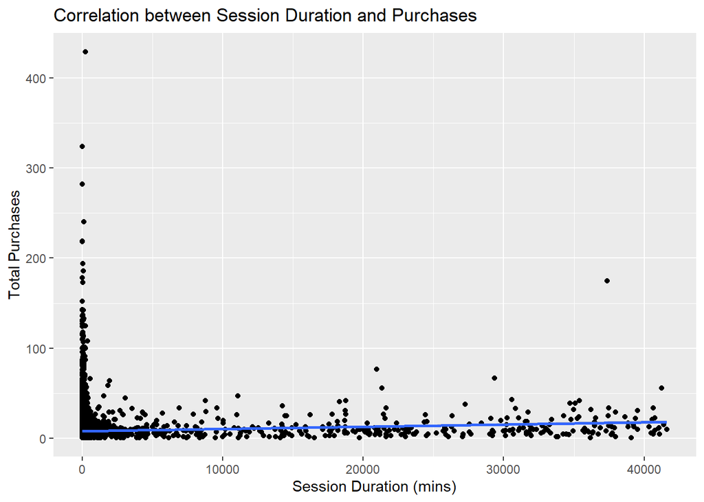

```r
# Plotting session duration vs. purchase correlation
ggplot(purchase_data, aes(x=average_session_duration, y=total_purchases)) +
  geom_point() +
  geom_smooth(method="lm") +
  labs(title="Correlation between Session Duration and Purchases", x="Session Duration (mins)", y="Total Purchases")
```

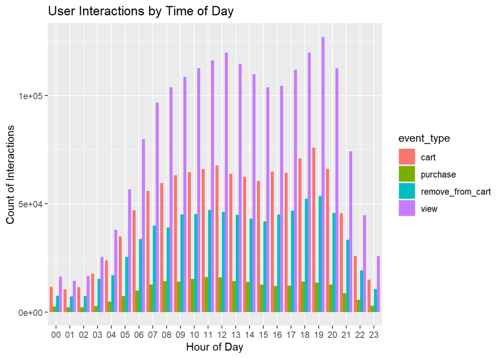

```r
# Interaction time of day
ggplot(interaction_time_of_day, aes(x=hour_of_day, y=count, fill=event_type)) +
  geom_bar(stat="identity", position="dodge") +
  labs(title="User Interactions by Time of Day", x="Hour of Day", y="Count of Interactions")
```

#### Correlation Analysis The correlation coefficient of 0.0580 suggests a very weak positive relationship between session duration and purchasing behavior. This indicates that longer sessions do not significantly correlate with an increase in purchases.

**Recommendations:** - **Target Quick Decisions:** Since session length has minimal impact on purchase decisions, focus on efficiency in product presentation and ease of the purchasing process. - **Experiment with User Experience Adjustments:** Test changes in site layout or checkout processes that might convert short-term visits into purchases more effectively.